[output not shown]

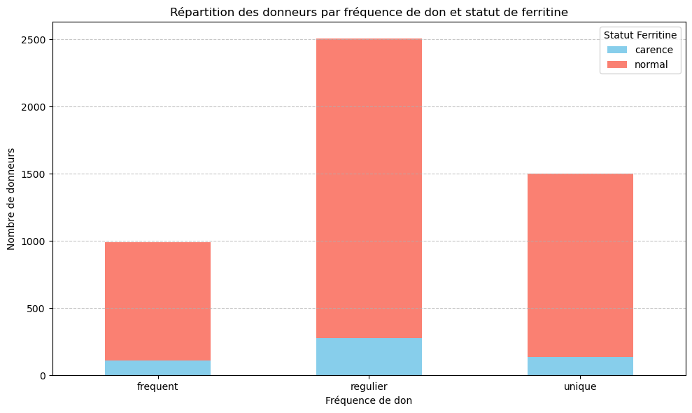

```python
import numpy as np
import pandas as pd
import matplotlib.pyplot as plt

# Simulation et analyse des données sur les donneurs de sang

# 1. Génération des données simulées
n_donneurs = 5000
np.random.seed(42)

# Données démographiques
ages = np.random.randint(18, 71, n_donneurs)
sexes = np.random.choice(['F', 'M'], size=n_donneurs, p=[0.55, 0.45])
freq_dons = np.random.choice(['unique', 'regulier', 'frequent'], size=n_donneurs, p=[0.3, 0.5, 0.2])

# Données biologiques
hb = np.where(sexes == 'M', np.random.normal(14.5, 1.2, n_donneurs), np.random.normal(13.2, 1.0, n_donneurs))
ferritine = np.where(sexes == 'M', np.random.normal(100, 50, n_donneurs), np.random.normal(30, 15, n_donneurs))

# 2. Calcul du statut de ferritine
def calc_statut_ferritine(ferritine, hb, sexe):
    if sexe == 'M' and ferritine < 15:
        return 'carence'
    elif sexe == 'F' and ferritine < 15:
        return 'carence'
    else:
        return 'normal'

statut_ferritine = [calc_statut_ferritine(f, h, s) for f, h, s in zip(ferritine, hb, sexes)]

# Création du DataFrame
data = pd.DataFrame({
    'Age': ages,
    'Sexe': sexes,
    'Frequence_don': freq_dons,
    'Hb': hb,
    'Ferritine': ferritine,
    'Statut_ferritine': statut_ferritine
})

# Aperçu des données simulées
print("Aperçu des données simulées :")
print(data.head())

# 3. Analyse statistique et graphique
# Répartition des donneurs par fréquence de don et statut de ferritine
carence_par_frequence = data.groupby(['Frequence_don', 'Statut_ferritine']).size().unstack()

# Visualisation
plt.figure(figsize=(10, 6))
carence_par_frequence.plot(kind='bar', stacked=True, figsize=(10, 6), color=['skyblue', 'salmon'])
plt.title('Répartition des donneurs par fréquence de don et statut de ferritine')
plt.ylabel('Nombre de donneurs')
plt.xlabel('Fréquence de don')
plt.xticks(rotation=0)
plt.legend(title='Statut Ferritine')
plt.grid(axis='y', linestyle='--', alpha=0.7)

# Affichage du graphique
plt.tight_layout()
plt.show()

# Conclusion : Les données simulées montrent une proportion plus élevée de carences en fer chez les donneurs fréquents.
```

# Présentation du travail du programme dans un contexte médical

Ce programme est conçu pour simuler et analyser des données sur la carence en fer chez les donneurs de sang. Il est utile pour explorer des tendances et comprendre les relations entre les habitudes de don et les niveaux de ferritine des donneurs, ce qui est crucial pour la prévention et la gestion de la carence en fer dans ce groupe.

## Objectif principal

- Simuler une population de donneurs de sang et analyser la prévalence de la carence en fer en fonction de facteurs tels que l'âge, le sexe, et la fréquence des dons.

## 1. Étapes du programme

### a. Génération des données simulées

- **Taille de l'échantillon** : 5 000 donneurs de sang simulés.
- **Variables démographiques** :
  - Âge : Entre 18 et 70 ans.
  - Sexe : Répartition de 55 % de femmes et 45 % d’hommes.
  - Fréquence des dons : Don unique, régulier (2-3 dons/an) ou fréquent (>3 dons/an).
- **Paramètres biologiques** :
  - Hémoglobine (Hb) : Moyenne plus élevée chez les hommes (14,5 g/dL) que chez les femmes (13,2 g/dL).
  - Ferritine : Moyenne simulée de 100 µg/L pour les hommes et 30 µg/L pour les femmes, avec une variabilité réaliste.

### c. Analyse statistique et visualisation

- Les données sont regroupées par fréquence de dons et statut de ferritine.
- **Graphique** :
  - Affiche la répartition des donneurs par fréquence de don (unique, régulier, fréquent) et par statut de ferritine (carence ou normal).
  - Permet de visualiser l’impact de la fréquence des dons sur le risque de carence en fer.

## 2. Résultats attendus

### a. Aperçu des données simulées

| Age | Sexe | Fréquence_don | Hb | Ferritine | Statut_ferritine |
| --- | --- | --- | --- | --- | --- |
| 56 | F | unique | 12.48 | 31.93 | normal |
| 69 | F | unique | 11.75 | 16.92 | normal |
| 46 | M | fréquent | 16.96 | 270.40 | normal |
| 32 | F | régulier | 15.24 | 14.31 | carence |
| 60 | F | fréquent | 14.41 | 20.92 | normal |

## 3. Utilité dans le domaine médical

### b. Sensibilisation et gestion des donneurs

- L’outil peut être utilisé pour sensibiliser les donneurs à l’importance de surveiller leurs niveaux de fer.
- Une approche personnalisée pour le suivi médical des donneurs peut être développée en s’appuyant sur des analyses similaires.

## 4. Conclusion

Ce programme représente une étape préliminaire essentielle dans l'étude de la carence en fer chez les donneurs de sang. Il offre une base pour des analyses plus poussées et peut être adapté avec des données réelles pour optimiser la gestion des donneurs et prévenir les complications liées à la carence en fer.